# 📘 **Explicación de Derivadas y Programación Lineal**

## ✨ **Conceptos clave:**

🔹 **Derivadas en python**  
🔹 **Funciones crecientes y decrecientes** 🔹 **Identificación de variables de decisión**  
🔹 **Cálculo de derivadas en Python**  
🔹 **Optimización con Programación Lineal**

### 🎯 **Objetivo:**

Comprender el concepto de derivadas, su aplicación en la identificación de funciones crecientes y decrecientes, y aprender a calcularlas usando **Python**. Además, exploraremos cómo aplicar la **programación lineal** para resolver problemas de optimización.

### 📌 **¿Qué necesitas?**

✔️ Conocimientos básicos de cálculo diferencial  
✔️ Familiaridad con **Python** y **Jupyter Notebook**  
✔️ Ganas de aprender y experimentar 🚀

**¡Comencemos! 🔥**

### **Origen de la derivada**

El concepto de derivada surge del trabajo de **Isaac Newton** y **Gottfried Wilhelm Leibniz** en el siglo XVII, quienes desarrollaron el cálculo diferencial e integral de manera independiente.

- **Newton** introdujo la derivada en el contexto de la **velocidad instantánea** y el movimiento de los cuerpos.
- **Leibniz** la formalizó con su notación dy/dx, que aún se usa hoy en día.

Ambos desarrollaron la idea de una tasa de cambio infinitesimal para resolver problemas de **movimiento, optimización y geometría**.

Dado un punto ( x=a ), la derivada ( f'(a) ) nos dice si la función está:

- **Creciendo** (( f'(a) > 0 )): la pendiente es positiva, y la curva sube.
- **Decreciendo** (( f'(a) < 0 )): la pendiente es negativa, y la curva baja.
- **Constante** (( f'(a) = 0 )): la pendiente es cero, lo que puede indicar un máximo, un mínimo o un punto de inflexión.

Visualmente:

https://www.geogebra.org/m/ve5pdft7

### **Ejemplos de derivadas**

1. **Derivada de una función lineal**:
   Si $$ f(x) = 3x + 2 $$ la derivada es:

$$ f'(x) = 3 $$

Como la función es lineal, su pendiente es constante.

2. **Derivada de una función cuadrática**:
   Si $$f(x) = x^2$$ la derivada es:

$$ f'(x) = 2x $$

Esto indica que la pendiente cambia en cada punto.

3. **Derivada de una función exponencial**:
   Si $$ f(x) = e^x$$ su derivada es:

$$ f'(x) = e^x $$

Lo que significa que su tasa de crecimiento es igual a su propio valor.

# **Formulario de Derivadas**

Si ( U ) y ( V ) son funciones diferenciables, y ( a, c ) son constantes, se aplican las siguientes reglas de derivación:

## **Algunas Reglas Básicas**

1. **Derivada de una constante**
   $$ \frac{d}{dx} (c) = 0 $$
2. **Regla de la potencia**
   $$ \frac{d}{dx} (x^n) = n x^{n-1}, \quad \text{para } n \in \mathbb{R} $$
3. **Derivada de una constante por una función**
   $$ \frac{d}{dx} (aU) = aU' $$
4. **Regla de la suma/resta**
   $$ \frac{d}{dx} (U \pm V) = U' \pm V' $$
5. **Regla del producto**
   $$ \frac{d}{dx} (U V) = U' V + U V' $$
6. **Regla del cociente**
   $$ \frac{d}{dx} \left( \frac{U}{V} \right) = \frac{U' V - U V'}{V^2}, \quad V \neq 0 $$
7. **Regla de la cadena**
   $$ \frac{d}{dx} f(g(x)) = f'(g(x)) \cdot g'(x) $$

# 📘 Introducción a las Derivadas en Python

## ✨ Reglas de Derivación

```python
import sympy as sp
from IPython.display import display, Markdown

# Definir la variable simbólica
x = sp.Symbol('x')
a, c = sp.symbols('a c')  # Constantes
```

### 1️⃣ Derivada de una constante

$$ \frac{d}{dx} (c) = 0 $$

```python
derivada_constante = sp.diff(c, x)
display(derivada_constante)
eval_constante = derivada_constante.subs(x, 2)
display(Markdown(f"Evaluación en x=2: {eval_constante}"))
```

$\displaystyle 0$

Evaluación en x=2: 0

### 2️⃣ Regla de la potencia

$$ \frac{d}{dx} (x^n) = n x^{n-1} $$

```python
potencia = x**3
derivada_potencia = sp.diff(potencia, x)
display(derivada_potencia)
eval_potencia = derivada_potencia.subs(x, 2)
display(Markdown(f"Evaluación en x=2: {eval_potencia}"))
```

$\displaystyle 3 x^{2}$

Evaluación en x=2: 12

### 3️⃣ Derivada de una constante por una función

$$ \frac{d}{dx} (a \sin x) = a \cos x $$

```python
constante_por_funcion = a * sp.sin(x)
derivada_constante_por_funcion = sp.diff(constante_por_funcion, x)
display(derivada_constante_por_funcion)
eval_const_func = derivada_constante_por_funcion.subs(x, sp.pi)
display(Markdown(f"Evaluación en x=π: {eval_const_func}"))
# Cosceno de pi igual a -1
# por lo tanto f(π)=a(−1)=−a
```

$\displaystyle a \cos{\left(x \right)}$

Evaluación en x=π: -a

### 4️⃣ Regla de la suma/resta

$$ \frac{d}{dx} (x^2 + e^x) = 2x + e^x $$

```python
suma_resta = x**2 + sp.exp(x)
derivada_suma_resta = sp.diff(suma_resta, x)
display(derivada_suma_resta)
eval_suma_resta = derivada_suma_resta.subs(x, 1)
display(Markdown(f"Evaluación en x=1: {eval_suma_resta}"))
```

$\displaystyle 2 x + e^{x}$

Evaluación en x=1: 2 + E

### 5️⃣ Regla del producto

$$ \frac{d}{dx} (x \cos x) = -x \sin x + \cos x $$

```python
producto = x * sp.cos(x)
derivada_producto = sp.diff(producto, x)
display(derivada_producto)
```

$\displaystyle - x \sin{\left(x \right)} + \cos{\left(x \right)}$

### 6️⃣ Regla del cociente

$$ \frac{d}{dx} \left( \frac{x^2 + 1}{x + 1} \right) $$

```python
cociente = (x**2 + 1) / (x + 1)
derivada_cociente = sp.diff(cociente, x)
display(derivada_cociente)
```

$\displaystyle \frac{2 x}{x + 1} - \frac{x^{2} + 1}{\left(x + 1\right)^{2}}$

### 7️⃣ Regla de la cadena

$$ \frac{d}{dx} (\sin(x^2 + 1)) = 2x \cos(x^2 + 1) $$

```python
compuesta = sp.sin(x**2 + 1)
derivada_compuesta = sp.diff(compuesta, x)
display(derivada_compuesta)
```

$\displaystyle 2 x \cos{\left(x^{2} + 1 \right)}$

# 🏭 **Identificación de Variables de Decisión y programación lineal**

Pensemos en el siguiente **Problema:** sobre **Producción de Sillas y Mesas**:

Una fábrica produce **sillas** y **mesas**. Cada silla genera **$5 de ganancia** y cada mesa **$8**. La producción está limitada por:

- **40 horas de trabajo disponibles**
- **30 unidades de madera disponibles**

Cada silla requiere **4 horas de trabajo** y **3 unidades de madera**, mientras que cada mesa requiere **5 horas de trabajo** y **6 unidades de madera**.

📌 **Objetivo:** Determinar cuántas **sillas** y **mesas** deben producirse para **maximizar la ganancia**.

## 🔍 **Identificación de las Variables de Decisión**

Para formular matemáticamente el problema, debemos identificar **qué cantidades queremos determinar**.

- **¿Qué estamos decidiendo?** → **Cuántas sillas y mesas producir**
- **Definición matemática:**
  - ( x_1 ) = Número de **sillas** a producir
  - ( x_2 ) = Número de **mesas** a producir

Estas variables definirán la solución del problema.

## 🎯 **¿Qué son las Variables de Decisión?**

Las **variables de decisión** son los valores desconocidos que necesitamos determinar para encontrar la mejor solución a un problema de optimización.  
Estas variables representan **acciones bajo nuestro control** y afectan la **función objetivo** y las **restricciones**.

### ✅ **Características de las Variables de Decisión**

✔️ **Deben ser cuantificables** (números reales o enteros).  
✔️ **Deben estar bajo nuestro control** dentro del problema.  
✔️ **Deben definir completamente la solución**.

En nuestro ejemplo:

- ( x_1 ) y ( x_2 ) **definen la cantidad de productos a fabricar**.
- La **función objetivo** dependerá de estas variables.
- Las **restricciones** como el tiempo y la madera también dependen de ( x_1 ) y ( x_2 ).

## 📌 **Pasos para Identificar las Variables de Decisión**

### **1️⃣ Leer y Comprender el Problema**

Antes de definir las variables, es fundamental entender:

- **¿Qué estamos maximizando o minimizando?** (Ejemplo: ganancias, costos, recursos).
- **¿Qué está bajo nuestro control?** (Ejemplo: unidades a producir, recursos a asignar).

### **2️⃣ Identificar las Cantidades a Determinar**

Las variables de decisión corresponden a **las incógnitas del problema**.  
Algunas preguntas clave:

- ¿Qué valores afectan directamente la solución?
- ¿Qué decisiones podemos tomar dentro del problema?

### **3️⃣ Definir las Variables Matemáticamente**

Las variables deben representarse con símbolos claros.  
En nuestro ejemplo:

- **( x_1 ) y ( x_2 )** determinan la solución.
- La **función objetivo** se expresa como: $$ \max \quad 5x_1 + 8x_2 $$ donde **( x_1 )** representa el número de **sillas** a producir y **( x_2 )** el número de **mesas**.
- Las **restricciones** del problema se escriben como ecuaciones en función de ( x_1 ) y ( x_2 ):
  - **Restricción de horas de trabajo**:
    Cada silla requiere **4 horas** y cada mesa **5 horas** de trabajo.
    Como solo hay **40 horas disponibles**, se plantea la restricción: $$ 4x_1 + 5x_2 \leq 40 $$
  - **Restricción de madera**:
    Cada silla requiere **3 unidades de madera** y cada mesa **6 unidades**.
    Como hay **30 unidades disponibles**, la restricción es: $$ 3x_1 + 6x_2 \leq 30 $$
  - **Restricciones de no negatividad**:
    No podemos producir una cantidad negativa de sillas o mesas, por lo que: $$ x_1 \geq 0, \quad x_2 \geq 0 $$

### **🛠 LHS (Left-Hand Side) y RHS (Right-Hand Side) en las Restricciones**

En cualquier ecuación o inecuación matemática, los términos pueden separarse en:

- **LHS (Left-Hand Side - Lado Izquierdo)**: Es la parte de la ecuación antes del signo de desigualdad o igualdad.
  - En la restricción de horas de trabajo:  
    **LHS** → ( 4x_1 + 5x_2 ) representa el **uso total de horas de trabajo**.
  - En la restricción de madera:  
    **LHS** → ( 3x_1 + 6x_2 ) representa el **uso total de madera**.
- **RHS (Right-Hand Side - Lado Derecho)**: Es el valor límite después del signo de desigualdad o igualdad.
  - En la restricción de horas de trabajo:  
    **RHS** → ( 40 ) representa el **máximo de horas disponibles**.
  - En la restricción de madera:  
    **RHS** → ( 30 ) representa la **cantidad de madera disponible**.

**Ejemplo completo de una restricción desglosada:** $$ 4x_1 + 5x_2 \leq 40 $$

- **LHS** → ( 4x_1 + 5x_2 ) (horas requeridas para producción).
- **RHS** → ( 40 ) (horas disponibles).
- **Signo ( \leq )** → Indica que **no podemos exceder las 40 horas disponibles**.

### **4️⃣ Verificar la Validez de las Variables**

- **¿Las variables permiten expresar la función objetivo?** ✅ Sí.
- **¿Las restricciones dependen de estas variables?** ✅ Sí.
- **¿Tienen sentido en el contexto del problema?** ✅ Sí.

# Ejemplo práctico de programación lineal

```python
from scipy.optimize import linprog

# Coeficientes de la función objetivo (maximizar 5x1 + 8x2)
c = [-5, -8]  # Se usan negativos porque linprog minimiza por defecto

# Coeficientes de las restricciones (LHS)
A = [
    [4, 5],  # Restricción de horas de trabajo [sillas, mesa]
    [3, 6]   # Restricción de madera [silla, mesa]
]

# Lado derecho de las restricciones (RHS)
b = [40, 30]

# Límites de las variables (no pueden ser negativas)
# x_bounds = [(lower_x1, upper_x1), (lower_x2, upper_x2)]
# None si no hay límite, o si el limite es infinito
x_bounds = [(0, None), (0, None)]

# Resolver el problema usando el método símplex
resultado = linprog(c, A_ub=A, b_ub=b, bounds=x_bounds, method="highs")

# Obtener los valores óptimos de las variables y la ganancia máxima
solucion_x1 = resultado.x[0]
solucion_x2 = resultado.x[1]
ganancia_maxima = -resultado.fun  # Se invierte el signo para obtener la maximización

solucion_x1, solucion_x2, ganancia_maxima
```

```
(np.float64(10.0), np.float64(0.0), 50.0)
```

# Veamoslo graficamente

Dada la inecuación:

$$ 4x_1 + 5x_2 \leq 40 $$

**Despejamos ( x_2 ):**

1. Restamos ( 4x_1 ) en ambos lados: $$ 5x_2 \leq 40 - 4x_1 $$
2. Dividimos todo entre **5**: $$ x_2 \leq \frac{40 - 4x_1}{5} $$

En **Python**, esta expresión se representaría como:

```
x2_vals_trabajo = (40 - 4*x1_vals) / 5
```

Lo mismo para madera

```
x2_vals_madera = (30 - 3*x1_vals) / 6
```

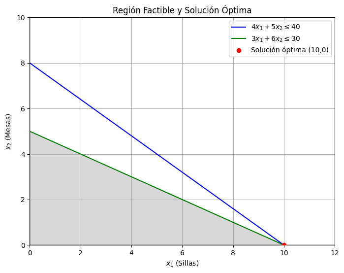

```python
import numpy as np
import matplotlib.pyplot as plt

# cada silla require 4 horas, en 40 horas prod
# Crear el espacio de valores para x1 y x2
x1_vals = np.linspace(0, 10, 100)

x2_vals_trabajo = (40 - 4*x1_vals) / 5  # Restricción de horas de trabajo despejando x2
x2_vals_madera = (30 - 3*x1_vals) / 6  # Restricción de madera despejando x2

# Configurar el gráfico
plt.figure(figsize=(8, 6))
plt.xlim(0, 12)
plt.ylim(0, 10)

# Dibujar las restricciones
plt.plot(x1_vals, x2_vals_trabajo, label=r'$4x_1 + 5x_2 \leq 40$', color="blue")
plt.plot(x1_vals, x2_vals_madera, label=r'$3x_1 + 6x_2 \leq 30$', color="green")

# Rellenar la región factible
plt.fill_between(x1_vals, np.minimum(x2_vals_trabajo, x2_vals_madera), 0, color='gray', alpha=0.3)

# Marcar la solución óptima
plt.scatter(10, 0, color="red", zorder=3, label="Solución óptima (10,0)")

# Etiquetas y título
plt.xlabel(r'$x_1$ (Sillas)')
plt.ylabel(r'$x_2$ (Mesas)')
plt.title("Región Factible y Solución Óptima")
plt.axhline(0, color='black', linewidth=1)
plt.axvline(0, color='black', linewidth=1)
plt.legend()
plt.grid()

# Mostrar el gráfico
plt.show()
```

### **📌 ¿Por qué despejamos ( x_2 ) y no ( x_1 ) en el método gráfico?**

En el **método gráfico** de **programación lineal**, despejamos **( x_2 ) en función de ( x_1 )** para **facilitar la representación en un plano cartesiano**. La razón principal es que **las gráficas en 2D se suelen trazar en función de ( x_1 ) (eje horizontal) y ( x_2 ) (eje vertical)**.

## 🔥 Ejercicios Integradores

Ahora es tu turno. Calcula las siguientes derivadas con sympy cada una en una celda de código y verifica tus resultados con `sympy.diff()`.

### **Ejercicio 1 - Derivadas de funciones con exponentes fraccionarios**

Calcula la derivada de la siguiente función y evalúala en ( x = 1 ):

$$ f(x) = x^{\frac{3}{2}} + 5x^{\frac{1}{3}} - e^{x^2} $$

### **Ejercicio 2 - Aplicación de la regla del producto y exponenciales**

Deriva la siguiente función y evalúa en ( x = 2 ):

$$ g(x) = (x^3 + 2x) e^{\sin x} $$

### **Ejercicio 3 - Regla del cociente con logaritmos y trigonometría**

Calcula la derivada de la siguiente función y evalúala en ( x = pi/4 ):

$$ h(x) = \frac{\ln(x^2 + 1)}{\tan x} $$

### **Ejercicio 4 - Regla de la cadena con funciones compuestas**

Aplica la regla de la cadena para obtener la derivada y evalúa en ( x = 1 ):

$$ k(x) = \sin^2(e^{x^3 + x}) $$

### **Ejercicio 5 - Derivadas en finanzas y economía**

Supongamos que una empresa modela su costo de producción con la siguiente función:

$$ C(x) = \frac{x^3 + 10x}{\ln(x+2)} $$

Calcula ( C'(x) ) y evalúa en ( x = 5 ) para determinar la tasa de cambio del costo en esa producción.

### **Ejercicio 6 - Aplicaciones en Machine Learning**

En redes neuronales, la función de activación **sigmoide** es:

$$ \sigma(x) = \frac{1}{1 + e^{-x}} $$

Calcula su derivada y evalúa en ( x = 0 ), ( x = 2 ), y ( x = -2 ).

```python
import sympy as sp

#EJERCICIO 1
x = sp.symbols('x')

f = x**(3/2) + 5*x**(1/3) - sp.exp(x**2)
derivada_f = sp.diff(f, x)
eval_f = derivada_f.subs(x, 1)
print("Ejercicio 1:")
print("Derivada:", derivada_f)
print("Evaluada en x=1:", eval_f)

#EJERCICIO 2
g = (x**3 + 2*x) * sp.exp(sp.sin(x))
g_derivada = sp.diff(g, x)
g_eval = g_derivada.subs(x, 2)
print("\nEjercicio 2:")
print("Derivada:", g_derivada)
print("Evaluada en x=2:", g_eval)

#EJERCICIO 3
h = sp.ln(x**2 + 1) / sp.tan(x)
h_derivada = sp.diff(h, x)
h_eval = h_derivada.subs(x, sp.pi/4)
print("\nEjercicio 3:")
print("Derivada:", h_derivada)
print("Evaluada en x=pi/4:", h_eval)

#EJERCICIO 4
k = sp.sin(sp.exp(x**3 + x))**2
k_derivada = sp.diff(k, x)
k_eval = k_derivada.subs(x, 1)
print("\nEjercicio 4:")
print("Derivada:", k_derivada)
print("Evaluada en x=1:", k_eval)

#EJERCICIO 5
C = (x**3 + 10*x) / sp.ln(x + 2)
C_derivada = sp.diff(C, x)
C_eval = C_derivada.subs(x, 5)
print("\nEjercicio 5:")
print("Derivada:", C_derivada)
print("Evaluada en x=5:", C_eval)

#EJERCICIO 6
sigma = 1 / (1 + sp.exp(-x))
sigma_derivada = sp.diff(sigma, x)
sigma_eval_1 = sigma_derivada.subs(x, 0)
sigma_eval_2 = sigma_derivada.subs(x, 2)
sigma_eval_3 = sigma_derivada.subs(x, -2)
print("\nEjercicio 6:")
print("Derivada:", sigma_derivada)
print("Evaluada en x=0:", sigma_eval_1)
print("Evaluada en x=2:", sigma_eval_2)
print("Evaluada en x=-2:", sigma_eval_3)
```

```
Ejercicio 1:
Derivada: 1.66666666666667/x**0.666666666666667 + 1.5*x**0.5 - 2*x*exp(x**2)
Evaluada en x=1: 3.16666666666667 - 2*E

Ejercicio 2:
Derivada: (3*x**2 + 2)*exp(sin(x)) + (x**3 + 2*x)*exp(sin(x))*cos(x)
Evaluada en x=2: 12*exp(sin(2))*cos(2) + 14*exp(sin(2))

Ejercicio 3:
Derivada: 2*x/((x**2 + 1)*tan(x)) + (-tan(x)**2 - 1)*log(x**2 + 1)/tan(x)**2
Evaluada en x=pi/4: -2*log(pi**2/16 + 1) + pi/(2*(pi**2/16 + 1))

Ejercicio 4:
Derivada: 2*(3*x**2 + 1)*exp(x**3 + x)*sin(exp(x**3 + x))*cos(exp(x**3 + x))
Evaluada en x=1: 8*exp(2)*sin(exp(2))*cos(exp(2))

Ejercicio 5:
Derivada: (3*x**2 + 10)/log(x + 2) - (x**3 + 10*x)/((x + 2)*log(x + 2)**2)
Evaluada en x=5: -25/log(7)**2 + 85/log(7)

Ejercicio 6:
Derivada: exp(-x)/(1 + exp(-x))**2
Evaluada en x=0: 1/4
Evaluada en x=2: exp(-2)/(exp(-2) + 1)**2
Evaluada en x=-2: exp(2)/(1 + exp(2))**2
```

### 📘 **Ejercicio 7 Programación Lineal**

En este ejercicio resolverás un problema de optimización lineal utilizando dos métodos:

- **Método Numérico**: Usando `scipy.optimize.linprog`.
- **Método Visual**: Representando gráficamente la región factible.

## 🔹 **Planteamiento del Problema**

Una empresa fabrica **cajas grandes** y **cajas pequeñas**. Cada caja grande genera **$7 de ganancia** y cada caja pequeña **$4**.

### **Restricciones:**

- **Disponibilidad de cartón**: Se tienen **50 unidades de cartón**.
- **Disponibilidad de mano de obra**: Hay **30 horas disponibles**.

Cada tipo de caja requiere los siguientes recursos:

- **Caja grande**: 5 unidades de cartón y 2 horas de trabajo.
- **Caja pequeña**: 3 unidades de cartón y 4 horas de trabajo.

📌 **Objetivo**: Determinar cuántas **cajas grandes** y **cajas pequeñas** deben producirse para **maximizar la ganancia**.

Resuelve el ejercicio en las celdas markdown/python que sean necesarias a partir de la siguiente:

```
Cantidad óptima de cajas grandes: 10.0
Cantidad óptima de cajas pequeñas: 0.0
Ganancia máxima: 70.0
```

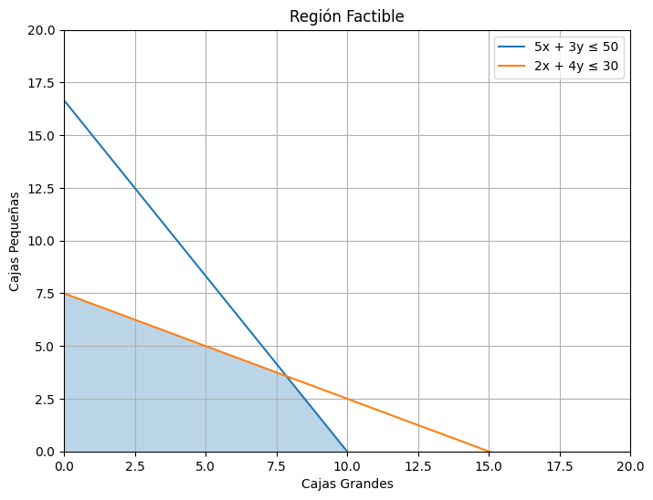

```python
#EJERCICIO 7

# Coeficientes de la función objetivo (7g + 4p)
c = [-7, -4]

# Restricciones de recursos
A = [[5, 3], [2, 4]] #De las unidades y las horas respectivamente
b = [50, 30] #De los recursos de cartón y de mano de obra

# Restricciones de no negatividad
g_bounds = (0, None)
p_bounds = (0, None)

# Resolver el problema por método simplex
res = linprog(c, A_ub=A, b_ub=b, bounds=[g_bounds, p_bounds], method='highs')
print("Cantidad óptima de cajas grandes:", res.x[0])
print("Cantidad óptima de cajas pequeñas:", res.x[1])
print("Ganancia máxima:", -res.fun)

# Configuración de gráfica
x_vals = np.linspace(0, 20, 100)
y1 = (50 - 5*x_vals) / 3
y2 = (30 - 2*x_vals) / 4

plt.figure(figsize=(8,6))
plt.plot(x_vals, y1, label='5x + 3y ≤ 50')
plt.plot(x_vals, y2, label='2x + 4y ≤ 30')
plt.fill_between(x_vals, np.minimum(y1, y2), 0, where=(y1>=0) & (y2>=0), alpha=0.3)
plt.xlim(0, 20)
plt.ylim(0, 20)
plt.xlabel('Cajas Grandes')
plt.ylabel('Cajas Pequeñas')
plt.title('Región Factible')
plt.legend()
plt.grid()
plt.show()
```

## 🔥 **Preguntas para Reflexión**

1️⃣ **Método Numérico:** ¿Cuáles son los valores óptimos de producción obtenidos con `linprog`? ¿Cómo se interpreta la ganancia máxima?

2️⃣ **Método Visual:** ¿Coincide la solución gráfica con la obtenida numéricamente? ¿Cómo podrías verificar la solución visualmente?

3️⃣ **Interpretación:** ¿Cómo impactarían cambios en la disponibilidad de cartón o mano de obra en la solución?

4️⃣ **Extensión:** ¿Cómo modificarías el modelo si la empresa decide producir un tercer tipo de caja con nuevas restricciones?

### 📘 **Ejercicio 8 (Avanzado de Programación Lineal)**

En este ejercicio resolverás un problema complejo de optimización lineal utilizando:

- **Método Numérico**: `scipy.optimize.linprog`.

El método visual no será necesario porque son 3 variables.

## 🔹 **Planteamiento del Problema**

Una empresa fabrica **tres tipos de productos**: **A, B y C**. Cada producto genera una ganancia distinta:

- **Producto A**: $10 de ganancia
- **Producto B**: $15 de ganancia
- **Producto C**: $25 de ganancia

### **Restricciones:**

- **Disponibilidad de materia prima**: 80 unidades disponibles.
- **Disponibilidad de horas de trabajo**: 100 horas disponibles.
- **Capacidad de producción diaria**: Máximo 30 unidades en total.

Cada producto requiere los siguientes recursos:

| Producto | Materia Prima | Horas de Trabajo |
| --- | --- | --- |
| A | 4 | 5 |
| B | 6 | 3 |
| C | 5 | 8 |

📌 **Objetivo**: Determinar cuántas unidades de cada producto deben producirse para **maximizar la ganancia**.

Resuelve el ejercicio en las celdas markdown/python que sean necesarias a partir de la siguiente:

```python
#EJERCICIO 8

c = [-10, -15, -25]  # Maximizar ganancias

A = [
    [4, 6, 5],  # Restricción de materia prima
    [5, 3, 8],  # Restricción de horas de trabajo
    [1, 1, 1]   # Restricción de capacidad de producción
]
b = [80, 100, 30]

# Restricciones de no negatividad
bounds = [(0, None), (0, None), (0, None)]

# Resolver el problema
res = linprog(c, A_ub=A, b_ub=b, bounds=bounds, method='highs')
print("Cantidad óptima de Producto A:", res.x[0])
print("Cantidad óptima de Producto B:", res.x[1])
print("Cantidad óptima de Producto C:", res.x[2])
print("Ganancia máxima:", -res.fun)
```

```
Cantidad óptima de Producto A: 0.0
Cantidad óptima de Producto B: 4.242424242424242
Cantidad óptima de Producto C: 10.90909090909091
Ganancia máxima: 336.3636363636364
```

## 🔥 **Preguntas para Reflexión**

1️⃣ **Método Numérico:** ¿Cuáles son los valores óptimos de producción obtenidos con `linprog`? ¿Cómo se interpreta la ganancia máxima? Los valores óptimos de producción de los productos A, B y C se obtienen con res.x, que representa la cantidad óptima de cada producto a fabricar. La ganancia máxima se obtiene con -res.fun, ya que el problema se resolvió como una minimización de la función objetivo negativa.

2️⃣ **Interpretación:** ¿Cómo cambiaría la solución si la disponibilidad de materia prima aumenta a 100 unidades? Si la disponibilidad de materia prima aumenta a 100 unidades, debemos modificar el valor en b = [100, 100, 30] y volver a ejecutar linprog. Esto podría permitir producir más productos, lo que aumentaría la ganancia máxima.

4️⃣ **Extensión:** Si agregáramos restricciones de almacenamiento o demanda mínima de productos, ¿cómo modificarías el modelo? Si agregamos restricciones de almacenamiento o demanda mínima, debemos modificar la matriz de restricciones A y el vector b.

Para almacenamiento, podríamos agregar una restricción como A.append([p1, p2, p3]) y b.append(capacidad_maxima), donde p1, p2, p3 son los espacios que cada producto ocupa. Para demanda mínima, podríamos agregar restricciones de tipo x >= min_demand, que se pueden manejar con límites en bounds.